# stepik_report_4

Alona Sychevska

10/15/2019

```r
library(psych)
library(ggplot2)
library(GGally)
library(qqplotr)
library(lattice)
library(Rmisc)
```

# Загрузка данных

```r
diabetes <- read.csv("~/code/scripts/R/stepik_projects/diabetes.csv")
```

# Проверка структури дата фрейма

```r
head(diabetes)
```

```
##   Pregnancies Glucose BloodPressure SkinThickness Insulin  BMI
## 1           6     148            72            35       0 33.6
## 2           1      85            66            29       0 26.6
## 3           8     183            64             0       0 23.3
## 4           1      89            66            23      94 28.1
## 5           0     137            40            35     168 43.1
## 6           5     116            74             0       0 25.6
##   DiabetesPedigreeFunction Age Outcome
## 1                    0.627  50       1
## 2                    0.351  31       0
## 3                    0.672  32       1
## 4                    0.167  21       0
## 5                    2.288  33       1
## 6                    0.201  30       0
```

```r
str(diabetes)
```

```
## 'data.frame':    768 obs. of  9 variables:
##  $ Pregnancies             : int  6 1 8 1 0 5 3 10 2 8 ...
##  $ Glucose                 : int  148 85 183 89 137 116 78 115 197 125 ...
##  $ BloodPressure           : int  72 66 64 66 40 74 50 0 70 96 ...
##  $ SkinThickness           : int  35 29 0 23 35 0 32 0 45 0 ...
##  $ Insulin                 : int  0 0 0 94 168 0 88 0 543 0 ...
##  $ BMI                     : num  33.6 26.6 23.3 28.1 43.1 25.6 31 35.3 30.5 0 ...
##  $ DiabetesPedigreeFunction: num  0.627 0.351 0.672 0.167 2.288 ...
##  $ Age                     : int  50 31 32 21 33 30 26 29 53 54 ...
##  $ Outcome                 : int  1 0 1 0 1 0 1 0 1 1 ...
```

#Определите тип каждого признака (количественные, порядковые, качественные).

Для количественных признаков определите, напрерывные они или дискретные (в том числе, дискретными могут стать непрерывные признаки, которые измерены с плохой точностью).

Лайфхак: если сомневаетесь, дискретный признак или нет, постройте его гистограмму с расзмером бина = 1. Если признак непрерывный, то одинаковые значения повторяются очень редко. Если дискретный, то вы увидите несколько высоких столбиков.

Pregnancies — количество беременностей, дискретный признак  
Glucose — Plasma glucose concentration a 2 hours in an oral glucose tolerance test, непрерывный  
BloodPressure — кровяное давление в (mm Hg), непрерывный признак  
SkinThickness — Triceps skin fold thickness (mm) — толщина кожи в мм, непрерывный  
Insulin — 2-Hour serum insulin (mu U/ml), непрерывный  
BMI — Body mass index (weight in kg/(height in m)^2), непрерывный  
DiabetesPedigreeFunction Age — возраст пациентов, дискретный признак  
Outcome – исход (0 — здоров, 1 — болен), качественный признак

```r
diabetes$Outcome <- factor(diabetes$Outcome)
levels(diabetes$Outcome) <- c("Здоров", "Болен")
```

#Определение размера датасета

```r
dim(diabetes)
```

```
## [1] 768   9
```

# Работа с пропущенными значениями

Я решила удалить строки с пропущенными значениями, хотя, если честно, не знаю, что в таких случаях точно делать. Возможно, подмену данных, но пока что я не опытна в этом, поэтому не пробовала.

```r
sum(diabetes$BloodPressure == 0)
```

```
## [1] 35
```

```r
sum(diabetes$Glucose == 0)
```

```
## [1] 5
```

```r
sum(diabetes$SkinThickness == 0)
```

```
## [1] 227
```

```r
sum(diabetes$Insulin == 0)
```

```
## [1] 374
```

```r
sum(diabetes$BMI == 0)
```

```
## [1] 11
```

```r
sum(diabetes$DiabetesPedigreeFunction == 0)
```

```
## [1] 0
```

Решила посмотреть перекрываются ли подмножины SkinThickness и Insulin

```r
sum(diabetes$SkinThickness == 0 & diabetes$Insulin == 0)
```

```
## [1] 227
```

```r
sum(diabetes$SkinThickness == 0 | diabetes$Insulin == 0)
```

```
## [1] 374
```

# Работа с NA

```r
diabetes$BloodPressure[diabetes$BloodPressure == "0"] <- NA
diabetes$Glucose[diabetes$Glucose == "0"] <- NA
diabetes$SkinThickness[diabetes$SkinThickness == "0"] <- NA
diabetes$Insulin[diabetes$Insulin == '0'] <- NA
diabetes$BMI[diabetes$BMI == '0'] <- NA
diabetes$DiabetesPedigreeFunction[diabetes$DiabetesPedigreeFunction == '0'] <- NA

colSums(is.na(diabetes))
```

```
##              Pregnancies                  Glucose            BloodPressure
##                        0                        5                       35
##            SkinThickness                  Insulin                      BMI
##                      227                      374                       11
## DiabetesPedigreeFunction                      Age                  Outcome
##                        0                        0                        0
```

```r
diabetes <- na.omit(diabetes)
```

# Oбщие статистики

Cовпадают ли ожидаемые признаков значения с реальными? Смотрим на статистики по группам, какие вы видите отличия между группами? Одинаковый ли размер этих групп?

Я использовала функцию describeBy, чтобы посмотреть на общие статистики, не учитывая данных с качественными признаками.

```r
describe(diabetes)
```

```
##                          vars   n   mean     sd median trimmed   mad   min
## Pregnancies                 1 392   3.30   3.21   2.00    2.82  1.48  0.00
## Glucose                     2 392 122.63  30.86 119.00  120.57 31.13 56.00
## BloodPressure               3 392  70.66  12.50  70.00   70.76 11.86 24.00
## SkinThickness               4 392  29.15  10.52  29.00   28.91 11.86  7.00
## Insulin                     5 392 156.06 118.84 125.50  135.74 80.80 14.00
## BMI                         6 392  33.09   7.03  33.20   32.77  6.67 18.20
## DiabetesPedigreeFunction    7 392   0.52   0.35   0.45    0.48  0.28  0.08
## Age                         8 392  30.86  10.20  27.00   29.21  7.41 21.00
## Outcome*                    9 392   1.33   0.47   1.00    1.29  0.00  1.00
##                             max  range  skew kurtosis   se
## Pregnancies               17.00  17.00  1.33     1.43 0.16
## Glucose                  198.00 142.00  0.51    -0.51 1.56
## BloodPressure            110.00  86.00 -0.09     0.75 0.63
## SkinThickness             63.00  56.00  0.21    -0.48 0.53
## Insulin                  846.00 832.00  2.15     6.21 6.00
## BMI                       67.10  48.90  0.66     1.50 0.35
## DiabetesPedigreeFunction   2.42   2.34  1.94     6.22 0.02
## Age                       81.00  60.00  1.39     1.68 0.52
## Outcome*                   2.00   1.00  0.71    -1.50 0.02
```

```r
describeBy(diabetes[, -c(9)], diabetes$Outcome, mat=T)
```

```
##                           item group1 vars   n        mean          sd   median
## Pregnancies1                 1 Здоров    1 262   2.7213740   2.6178435   2.0000
## Pregnancies2                 2  Болен    1 130   4.4692308   3.9161531   3.0000
## Glucose1                     3 Здоров    2 262 111.4312977  24.6421331 107.5000
## Glucose2                     4  Болен    2 130 145.1923077  29.8393882 144.5000
## BloodPressure1               5 Здоров    3 262  68.9694656  11.8928414  70.0000
## BloodPressure2               6  Болен    3 130  74.0769231  13.0215179  74.0000
## SkinThickness1               7 Здоров    4 262  27.2519084  10.4341346  27.0000
## SkinThickness2               8  Болен    4 130  32.9615385   9.6427696  33.0000
## Insulin1                     9 Здоров    5 262 130.8549618 102.6261767 105.0000
## Insulin2                    10  Болен    5 130 206.8461538 132.6998982 169.5000
## BMI1                        11 Здоров    6 262  31.7507634   6.7949708  31.2500
## BMI2                        12  Болен    6 130  35.7776923   6.7346871  34.6000
## DiabetesPedigreeFunction1   13 Здоров    7 262   0.4721679   0.2992397   0.4135
## DiabetesPedigreeFunction2   14  Болен    7 130   0.6255846   0.4059098   0.5460
## Age1                        15 Здоров    8 262  28.3473282   8.9890084  25.0000
## Age2                        16  Болен    8 130  35.9384615  10.6347054  33.0000
##                               trimmed        mad    min     max   range
## Pregnancies1                2.3238095  1.4826000  0.000  13.000  13.000
## Pregnancies2                4.0480769  3.7065000  0.000  17.000  17.000
## Glucose1                  109.6190476 24.4629000 56.000 197.000 141.000
## Glucose2                  145.8557692 35.5824000 78.000 198.000 120.000
## BloodPressure1             69.0238095 11.8608000 24.000 106.000  82.000
## BloodPressure2             74.3076923 11.8608000 30.000 110.000  80.000
## SkinThickness1             26.8190476 11.8608000  7.000  60.000  53.000
## SkinThickness2             32.9519231 10.3782000  7.000  63.000  56.000
## Insulin1                  112.6904762 64.4931000 15.000 744.000 729.000
## Insulin2                  184.2788462 74.8713000 14.000 846.000 832.000
## BMI1                       31.4800000  7.4871300 18.200  57.300  39.100
## BMI2                       35.2173077  5.0408400 22.900  67.100  44.200
## DiabetesPedigreeFunction1   0.4337333  0.2498181  0.085   2.329   2.244
## DiabetesPedigreeFunction2   0.5698654  0.3291372  0.127   2.420   2.293
## Age1                       26.6000000  4.4478000 21.000  81.000  60.000
## Age2                       35.1057692 11.8608000 21.000  60.000  39.000
##                                  skew    kurtosis          se
## Pregnancies1               1.48451379  2.18844749  0.16173091
## Pregnancies2               0.80057307 -0.13059510  0.34346935
## Glucose1                   0.71751951  0.47870818  1.52239607
## Glucose2                  -0.13608900 -0.94797989  2.61708747
## BloodPressure1            -0.15617881  0.65519311  0.73474220
## BloodPressure2            -0.13210344  0.89564257  1.14206267
## SkinThickness1             0.34340300 -0.53246642  0.64462299
## SkinThickness2             0.09558206 -0.03439163  0.84572684
## Insulin1                   2.48088816  8.71755853  6.34026637
## Insulin2                   1.84331619  4.20184170 11.63855098
## BMI1                       0.42836837  0.10944659  0.41979470
## BMI2                       1.34720706  3.67719546  0.59067113
## DiabetesPedigreeFunction1  1.86699261  6.37234236  0.01848709
## DiabetesPedigreeFunction2  1.75334658  4.51393508  0.03560065
## Age1                       2.18516679  6.05988771  0.55534280
## Age2                       0.56369071 -0.83695039  0.93272537
```

# Строим scatterplot для всех пар

Долго его разглядываем с точки зрения outliers, неоднородностей, вида распределений, вида зависимостей (линейные/нелинейные) и прочие

Пока что что-то не очень красиво и не совсем понятно, что происходит, буду работать. Может надо что-то поменять?

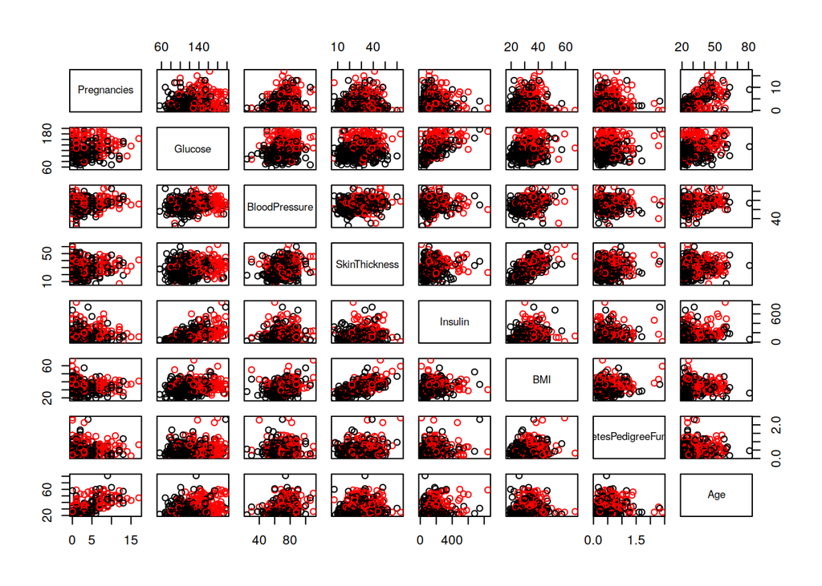

```r
pairs(diabetes[, -c(9)], col=diabetes$Outcome)
```

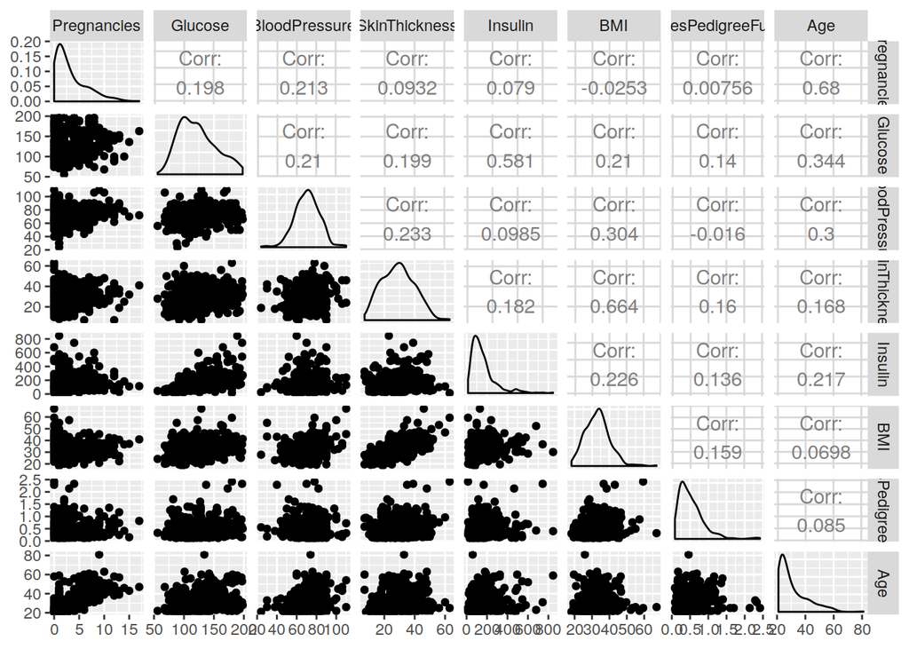

```r
ggpairs(diabetes[, -c(9)])
```

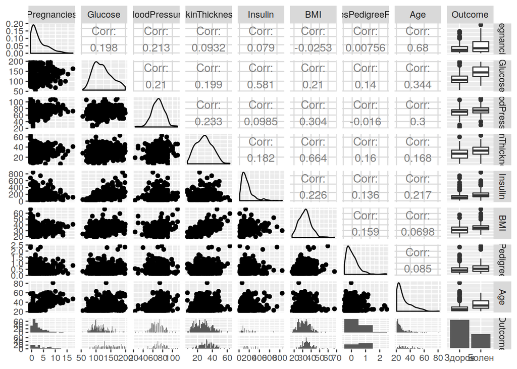

```r
#Не знаю как изменить размер графика и сделать его больше?
ggpairs(diabetes, lower = list(combo = wrap("facethist", binwidth = 1, mapping=aes(colour=Outcome, alpha=0.4))))
```

# qqplots, нормальность распределения

1. Pregnancies. Это распределение имеет толстый хвост справа и тонкий хвост слева. Имеет ступенчастую структуру.
2. Glucose. Распределение имеет тонкие концы с обеих сторон. S-подобная форма, не похоже чтобы оно было нормальным.
3. BloodPressure. Распределение имеет толстые концы с обеих сторон и ступенчастую структуру. Можно попробовать логарифмировать.
4. SkinThickness. Распределение имеет тонкие хвосты с обеих сторон и ступенчастую структуру.
5. Insulin. Сложно что-то сказать о нормальности распределения. Имеет толстый хвост справа и тонкий слева. Попробую логарифмировать.
6. BMI. Тонкий хвост слева и толстый справа, но похоже на нормальное распредедение (?)
7. DiabetesPedigreeFunction. Тонкий хвост слева и толстый справа.
8. Age. Не похоже на нормальное распределение. Тонкий хвост слева и толстый справа. S-подобная форма.

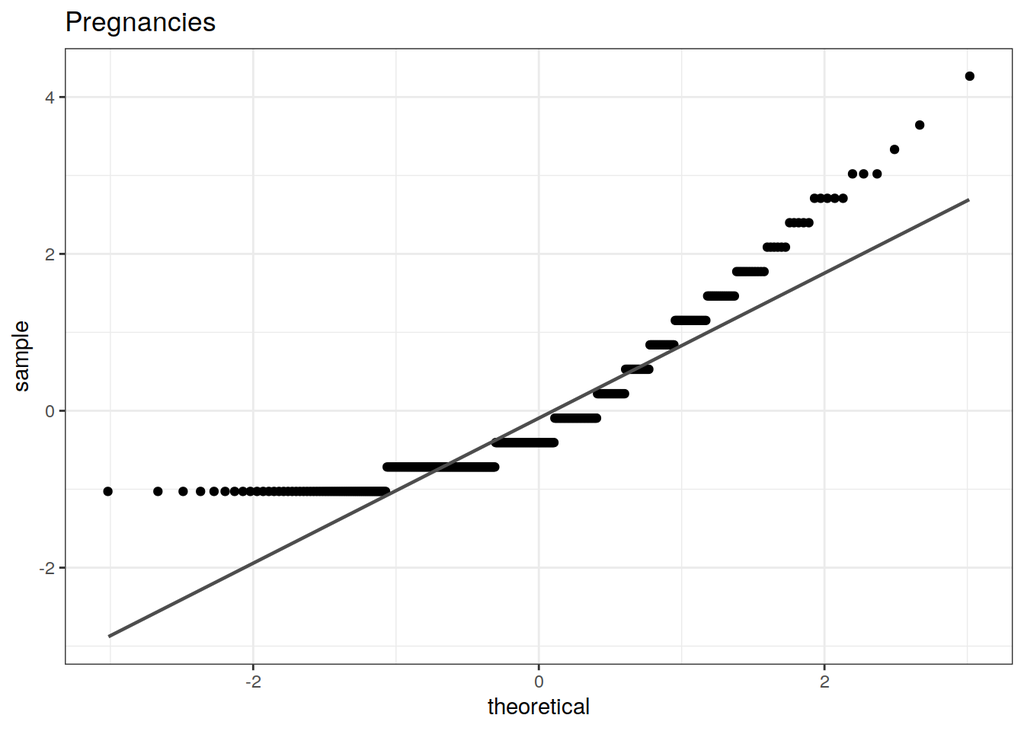

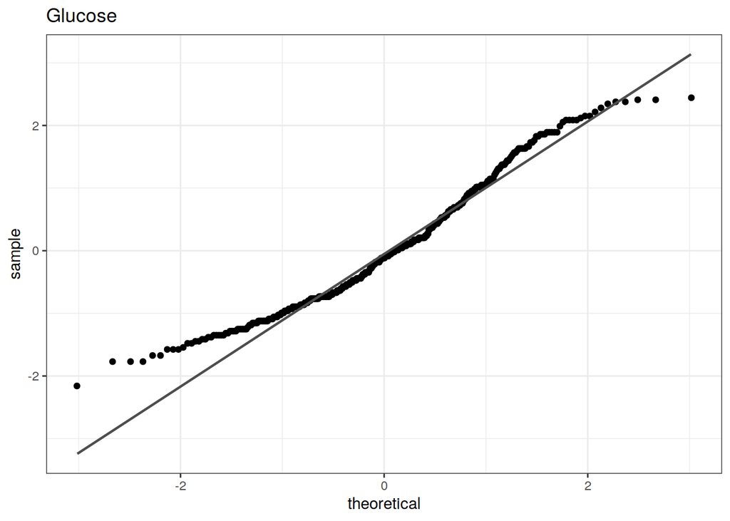

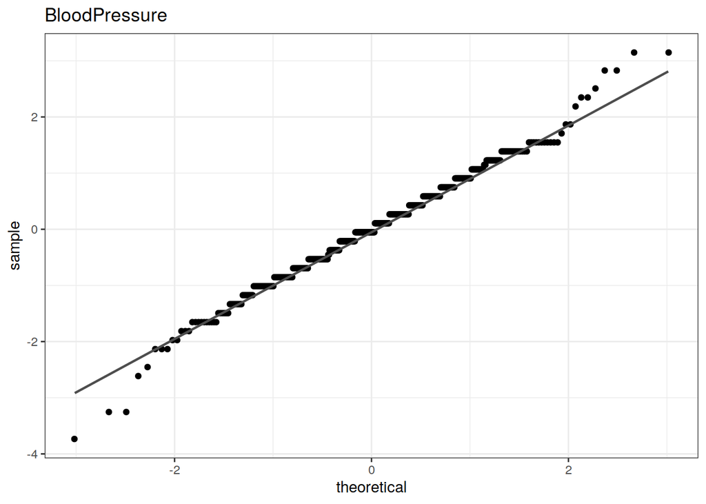

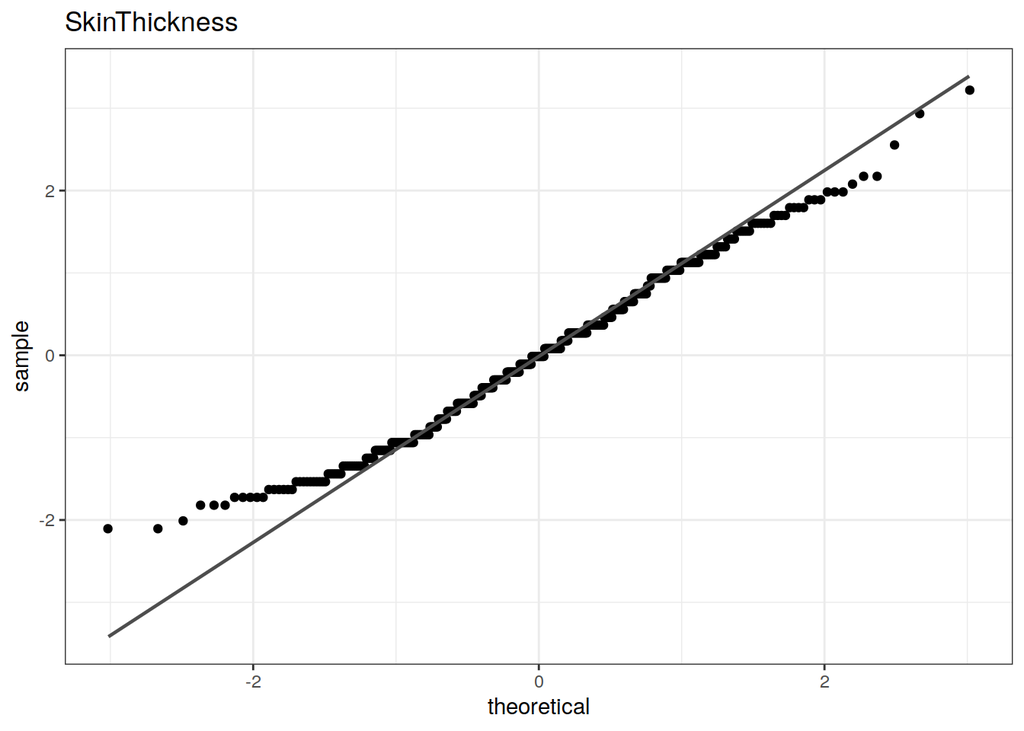

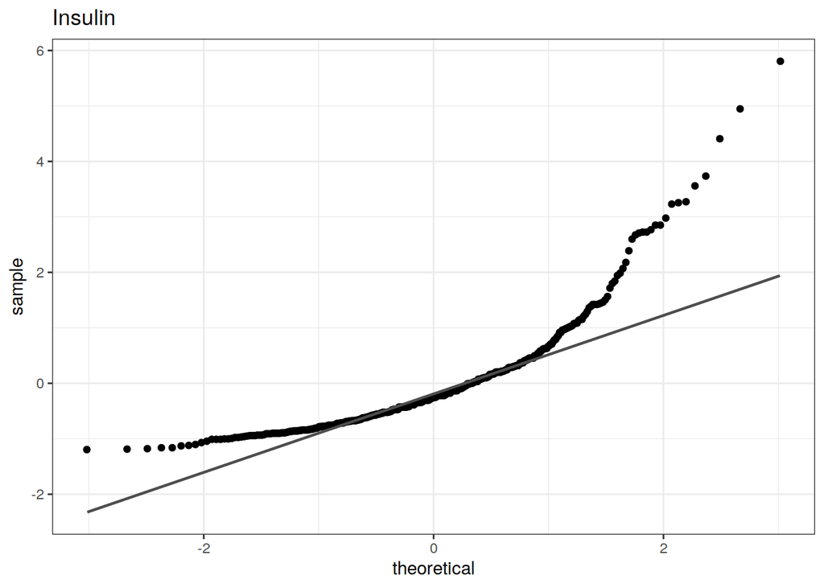

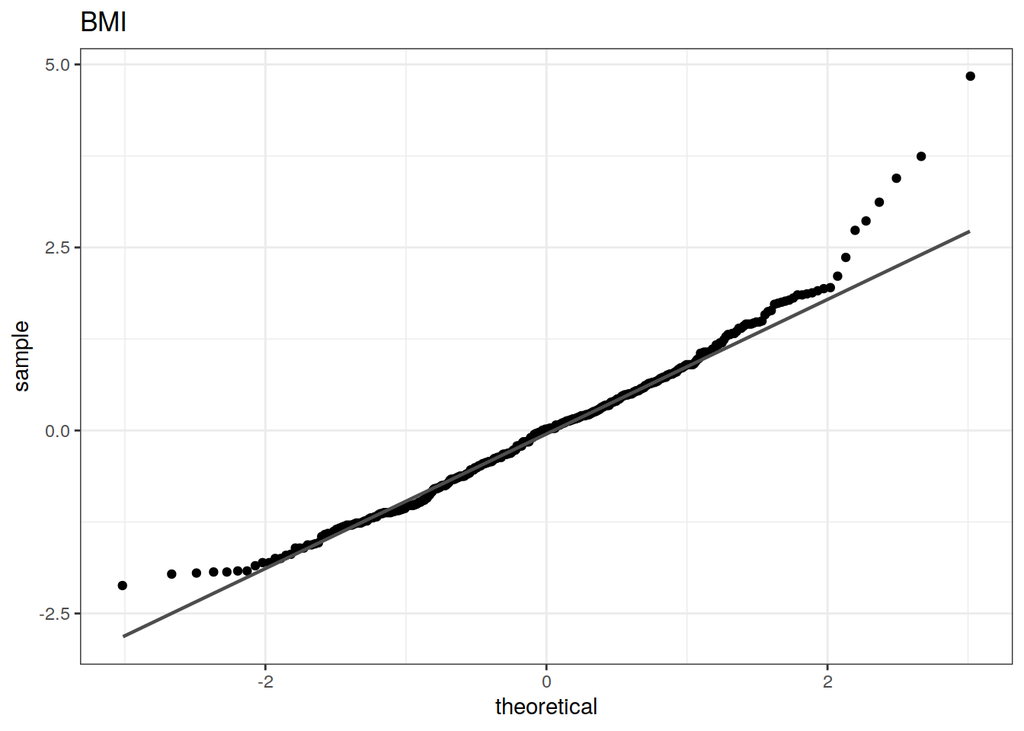

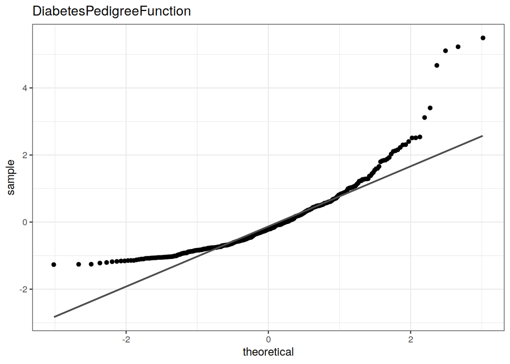

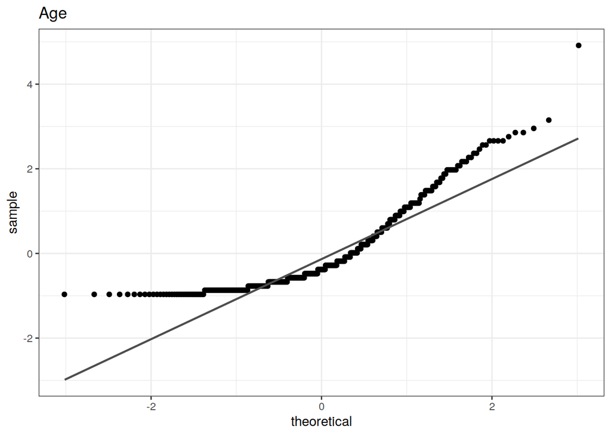

```r
sapply(colnames(diabetes), function(col) {
  data <- diabetes[, col]
  if (is.numeric(data)) {
    ggplot() + aes(sample = scale(data)) +
      stat_qq() +
      stat_qq_line() +
      ggtitle(col)+
      theme_bw()
  }
})
```

# Eсли видите тяжелый хвост, попробуйте логарифмировать признак.

Брать log_qqplot(“Pregnancies”) имеет мало смысла, потому что Pregnancies распределены по power law, похоже, что добавления каждого ребенка уменьшает количество женщин приблизительно в 1.18 раза.

По признаку BloodPressure никаких положительных изменений не произошло после логарифмирования.

По признаку Insulin после логарифмирования распределение стало лучше, но не идеально: небольшой горбик, но нету хвоста справа.

По признаку BMI: стало лучше, хвост остался, но уже поменьше.

По признаку DiabetesPedigreeFunction: стало лучше, но все равно остались хвосты.

По признаку Age: после логарифмирования все равно не похоже на нормальное распределение, но тяжелый хвост справа стал меньше.

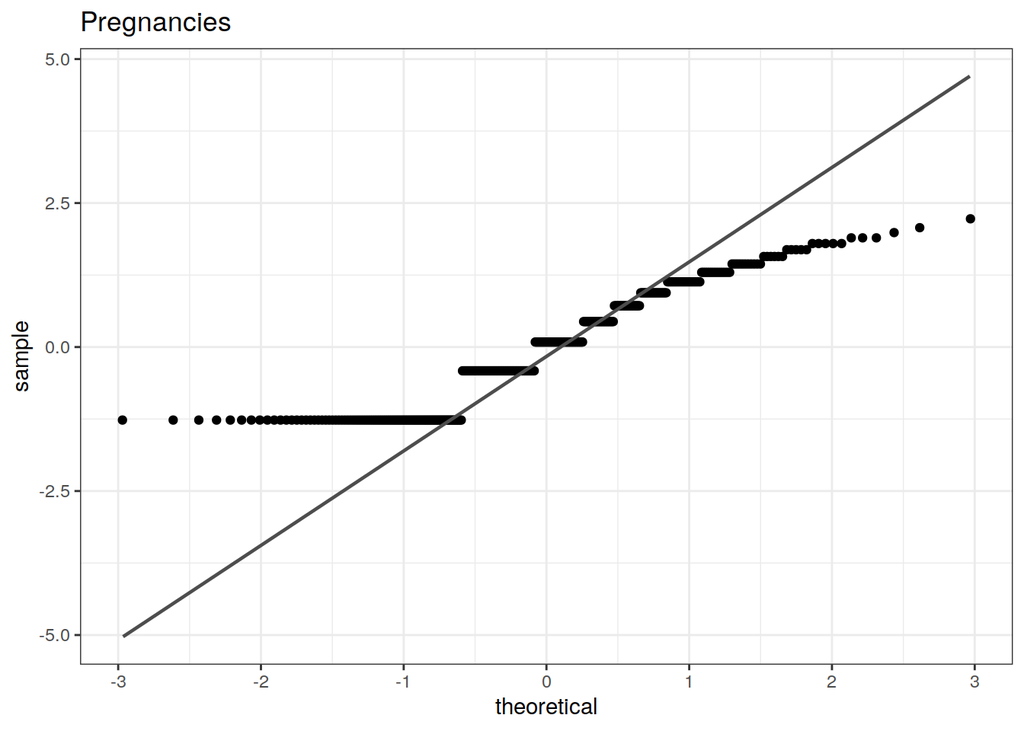

```r
log_qqplot <- function(col) {
  data <- diabetes[diabetes[col] != 0, ]
  ggplot() + aes(sample = scale(log(data[, col]))) +
    stat_qq() +
    stat_qq_line() +
    ggtitle(col) +
    theme_bw()
}

log_qqplot("Pregnancies")
```

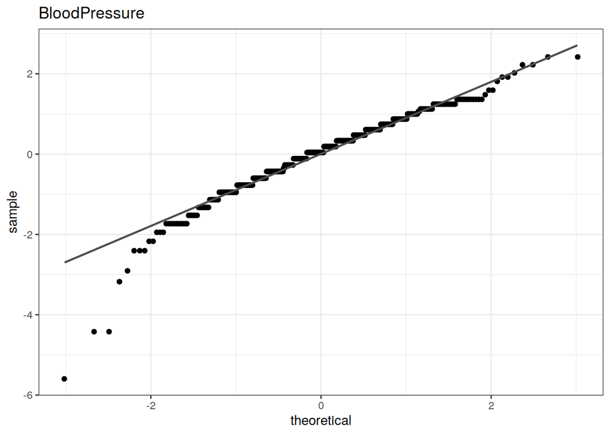

```r
log_qqplot("BloodPressure")
```

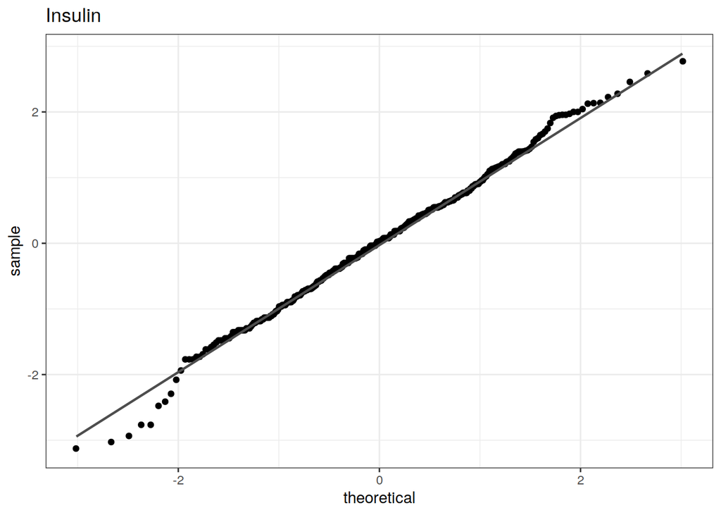

```r
log_qqplot("Insulin")
```

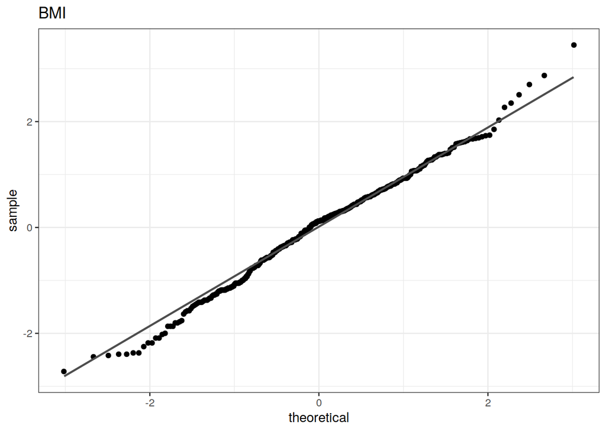

```r
log_qqplot("BMI")
```

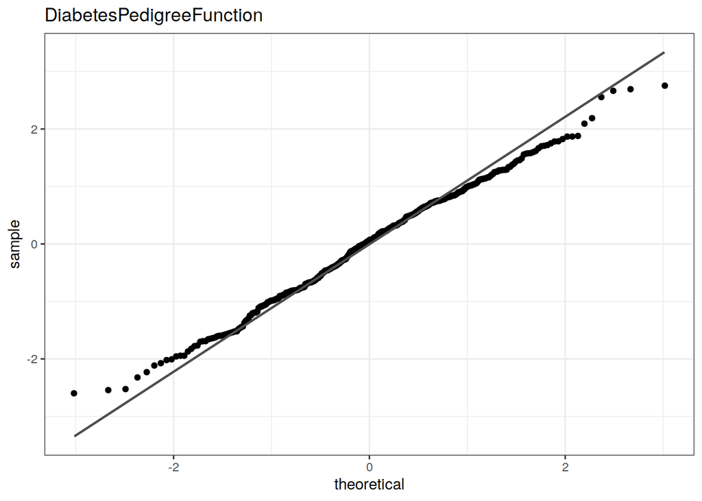

```r
log_qqplot("DiabetesPedigreeFunction")
```

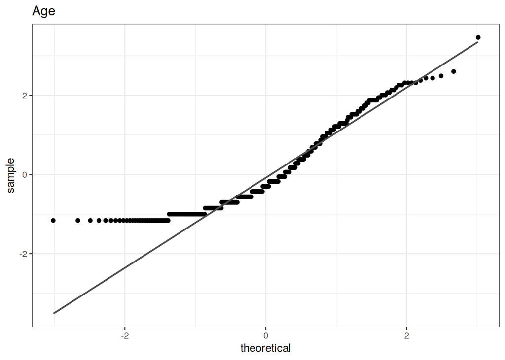

```r
log_qqplot("Age")
```

# Корреляции

1. Посмотрите еще раз на свой scatterplot по всем парам, какие зависимости вы видите в данных? Не забудьте, что при неоднородных данных изучать зависимости имеет смысл только внутри групп по-отдельности

Можно увидеть что-то похожее на линейную зависимость по переменным Age и Pregnancies; BMI и SkinThickness. Я думаю, что, возможно, если разбить по категориальной переменной больной-здоров, то могла бы быть видна линейная зависимость между переменными Insulin и Glucose.

2. Начинаем с анализа линейных зависимостей. Постройте матрицу корреляций и посмотрите, видите ли там большие значения или значения близкие к нулю

Если посмотреть на даную матрицу, можно увидеть большую корреляцию между переменными Insulin и Glucose – 0,581; Age и Pregnancies – 0,679; BMI и SkinThickness – 0,664. Так же можно заметить очень низкую корреляцию между переменными BMI и Pregnancies – (-0,025); DiabetesPedigreeFunction и Pregnancies – 0,00756; DiabetesPedigreeFunction и BloodPressure – (-0,0159); BMI и Age – 0,0698.

```r
cor(diabetes[, sapply(diabetes, is.numeric)])
```

```
##                           Pregnancies   Glucose BloodPressure SkinThickness
## Pregnancies               1.000000000 0.1982910     0.2133548     0.0932094
## Glucose                   0.198291043 1.0000000     0.2100266     0.1988558
## BloodPressure             0.213354775 0.2100266     1.0000000     0.2325712
## SkinThickness             0.093209397 0.1988558     0.2325712     1.0000000
## Insulin                   0.078983625 0.5812230     0.0985115     0.1821991
## BMI                      -0.025347276 0.2095159     0.3044034     0.6643549
## DiabetesPedigreeFunction  0.007562116 0.1401802    -0.0159711     0.1604985
## Age                       0.679608470 0.3436415     0.3000389     0.1677611
##                             Insulin         BMI DiabetesPedigreeFunction
## Pregnancies              0.07898363 -0.02534728              0.007562116
## Glucose                  0.58122301  0.20951592              0.140180180
## BloodPressure            0.09851150  0.30440337             -0.015971104
## SkinThickness            0.18219906  0.66435487              0.160498526
## Insulin                  1.00000000  0.22639652              0.135905781
## BMI                      0.22639652  1.00000000              0.158771043
## DiabetesPedigreeFunction 0.13590578  0.15877104              1.000000000
## Age                      0.21708199  0.06981380              0.085029106
##                                 Age
## Pregnancies              0.67960847
## Glucose                  0.34364150
## BloodPressure            0.30003895
## SkinThickness            0.16776114
## Insulin                  0.21708199
## BMI                      0.06981380
## DiabetesPedigreeFunction 0.08502911
## Age                      1.00000000
```

ПРЕДУПРЕЖДЕНИЕ: пока вы не сделали статистический тест, вы не можете говорить, что корреляция 0.816 большая и не можете ничего интерпретировать!! Пока просто смотрим.

3. Постройте матрицу корреляций Спирмена. Похожа ли эта матрица на обычную матрицу корреляций?

```r
cor(diabetes[, sapply(diabetes, is.numeric)], method = "spearman")
```

```
##                          Pregnancies    Glucose BloodPressure SkinThickness
## Pregnancies               1.00000000 0.19048148    0.15241404    0.05475868
## Glucose                   0.19048148 1.00000000    0.23660931    0.21583824
## BloodPressure             0.15241404 0.23660931    1.00000000    0.25010618
## SkinThickness             0.05475868 0.21583824    0.25010618    1.00000000
## Insulin                   0.12315371 0.65895822    0.13163895    0.24114499
## BMI                      -0.06555144 0.19907115    0.31742747    0.67439293
## DiabetesPedigreeFunction  0.01171335 0.08934581   -0.02089194    0.09304947
## Age                       0.63365655 0.35030470    0.32924408    0.24150672
##                            Insulin         BMI DiabetesPedigreeFunction
## Pregnancies              0.1231537 -0.06555144               0.01171335
## Glucose                  0.6589582  0.19907115               0.08934581
## BloodPressure            0.1316389  0.31742747              -0.02089194
## SkinThickness            0.2411450  0.67439293               0.09304947
## Insulin                  1.0000000  0.30090608               0.13151530
## BMI                      0.3009061  1.00000000               0.09624242
## DiabetesPedigreeFunction 0.1315153  0.09624242               1.00000000
## Age                      0.2607474  0.16696290               0.10298412
##                                Age
## Pregnancies              0.6336566
## Glucose                  0.3503047
## BloodPressure            0.3292441
## SkinThickness            0.2415067
## Insulin                  0.2607474
## BMI                      0.1669629
## DiabetesPedigreeFunction 0.1029841
## Age                      1.0000000
```

4. Если при сравнении буду найдены заметные различия между корреляцией Спирмена и Пирсона, то объясните причину